# Statistical Critique 1

Due April 23, 2023 by midnight

# 1 Assignment Details

In your first statistical critique will focus on critiquing a key aspect of any statistical argument—data visualization. You have explored data visualizations over the last two weeks, thinking about what makes a plot more or less clear. You will use your knowledge of data visualizations to provide a critique for two different styles of visualizations, (1) a “pop” visualization, and (2) a “scientific” visualization.

## 1.1 Including your Visualizations

You are expected to include the two visualizations you decide to critique. These visualizations must be included in the paragraph surrounding your critique, not at the end of your document.

### Getting your visualizations

For the New York Times visualization, you can left click on the image and save it to your computer.

[figure not shown]

Figure 1: Options when left clicking on NYT visualization – either copy the image or save it to your computer

For the visualization from your research article, you may need to take screenshot of the page and crop it to only include the image.

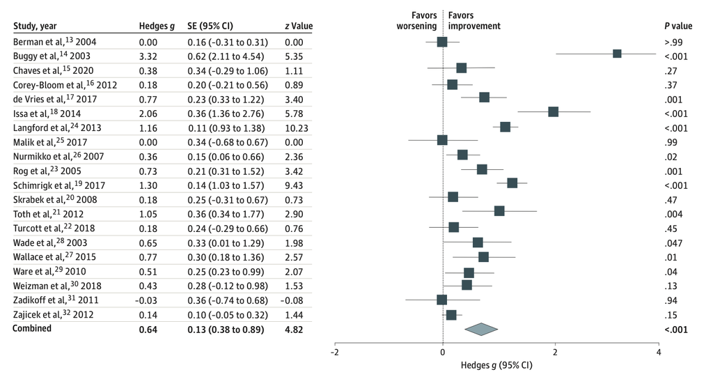

Figure 2: Cropped image from scientific article

## 1.2 Submission

You are allowed to use any text editing software to make your critique (e.g., Word, Pages, Google Docs), but your submission **must be a PDF**. If you are unsure how to save your file as a PDF, I recommend using Google!

# 2 Part One: Pop Visualizations

It is common for blogs and online news to use visualizations to convey information to their readers. In this segment you will select a “pop” visualization and provide a critique of what the visualization does well and where it could be improved.

## 2.1 Getting Started

1. Go to the [What’s Going on in This Graph website](https://www.nytimes.com/column/whats-going-on-in-this-graph)
2. Scroll through the weekly graphs and click on a plot that you are interested in
3. Save the image to your computer (as instructed above)

## 2.2 Visualization Critique

Your critique of the visualization you selected needs to address the following questions:

1. What aesthetics are being used in the plot?

**Tip**

Remember: `aes`thetics map **variables** to aspects of the plot

2. Name **at least two** things the visualization does well — What makes the visualization clear to the reader?
3. Name **at least two** ways the visualization could be improved — What would the reader struggle to understand?

# 3 Part Two: Scientific Visualizations

It is becoming increasingly common for scientific articles to be required to provide visualizations of the data alongside a statistical analysis. In this segment, you will use the scientific article you selected in Week 1 (your submission to the *Week 1: Statistics in Your Field* assignment) and provide a critique of what the visualization does well and where it could be improved.

## 3.1 Getting Started

1. Access the research article you selected in Week 1. If you cannot find it on your computer, go to the [Week 1: Statitics in Your Field assignment](https://canvas.calpoly.edu/)
2. Save the image to your computer (as instructed above)

## 3.2 Visualization Critique

Your critique of the visualization you selected needs to address the following questions:

1. What aesthetics are being used in the plot?

**Tip**

Remember: `aes`thetics map **variables** to aspects of the plot

2. Name **at least two** things the visualization does well — What makes the visualization clear to the reader?
3. Name **at least two** ways the visualization could be improved — What would the reader struggle to understand?

**Caution**

If the article you selected **does not** have a visualization, you are permitted to substitute a *table* for a visualization. You will address the following questions:

1. What aesthetics are being used in the table? Similar to a visualization, the aesthetics of a table are variables being mapped to aspects of the table.
2. Name **at least two** things the table does well — What makes the table clear to the reader?
3. Name **at least two** ways the table could be improved — What would the reader struggle to understand?